# Bayesian Modelling of grouped data

Emanuel Michele Soda

2022-05-14

# Introduction

*Bayesian statistics* is sub-field of statistics based on the Bayesian interpretation of probability where probability expresses a degree of belief in an event. Bayesian statistics has some difference compare to the more common frequentist. In brief we have:

- *Frequentist* makes predictions on the underlying truths of the experiment using only data from the current experiment.
- *Bayesian* take a different approach where paste knowledge are take into consideration.

Knowing that the main difference between the frequentist and bayesian approach is that the latter specifies that there is some prior probability.

In this markdown we will have a look to the bayesian in order to create a regression model to predict a two class dataset. As we will see thanks to the bayesian statistics and in particular using the *Markov chain Monte Carlo* (*MCMC*) wee will be able to see how confident we are in the modeling of our data.

# Utility Function

Before jump to the analysis we will create two utility functions. The create_prediction is a function to create the prediction based on the  
bayesian model while the plot_bayesian_model is a utility function to visualize the model while.

```r
create_prediction <- function(tbl){
    tbl %>%
        predict(
            new_data = sim_data,
            type = "raw",
            opts = list(
                allow_new_levels = TRUE,
                probs = c(0.025, 0.17, 0.83, 0.975)
            )
        ) %>%
            as_tibble() %>%
            janitor::clean_names() %>%
            select(-est_error) %>%
            set_names(c(".pred", ".pred_lower_95", ".pred_lower_66",
                        ".pred_upper_66", ".pred_upper_95")) %>%
            bind_cols(sim_data)
}
plot_bayesian_model <- function(tbl){
    ggplot(tbl, aes(x, y, group = type)) +
        geom_ribbon(aes(ymax = .pred_upper_95, ymin = .pred_lower_95,),
                    alpha = 0.5, fill = "#0096C7") +
        geom_ribbon(aes(ymax = .pred_upper_66, ymin = .pred_lower_66),
                    alpha = 0.5, fill = "#0077B6") +

        geom_point(aes(col = type), alpha = 0.5) +
        geom_line(aes(y = .pred), size = 1, col = "#CAF0F8") +
        scale_color_tq() +
        scale_y_continuous(labels = scales::comma) +
        theme(legend.position = "none")
}
```

# Read Data

First of all we will read the CSV file. This data are simulated data with no particular meaning. Hence we will not spend to much time trying to interpret those data. The focus of this markdown is to have a look to the Bayesian model and to see how increasing the complexity of the model leads to better results.

```r
sim_data <- read_csv("data/bayesian_data_2.csv")
sim_data
```

```
## # A tibble: 385 × 3
##         x       y type
##     <dbl>   <dbl> <chr>
##  1  0.266   4.10  sim_1
##  2  0.697   0.111 sim_1
##  3  0.735  -3.84  sim_1
##  4  0.770   1.94  sim_1
##  5  2.30   -7.83  sim_1
##  6  2.63  -18.2   sim_1
##  7 -0.691   0.810 sim_1
##  8  0.706   2.26  sim_1
##  9  0.964   3.22  sim_1
## 10  2.49  -18.1   sim_1
## # … with 375 more rows
```

# Data Visualization

As we can see our data are clustered in two groups:

For this reason we can already say that the performance of a global model will not be good. Anyway to see the improvement we will begin with this very basic model.

For what concern the other column we have have a independent variable x and a dependent variable y.

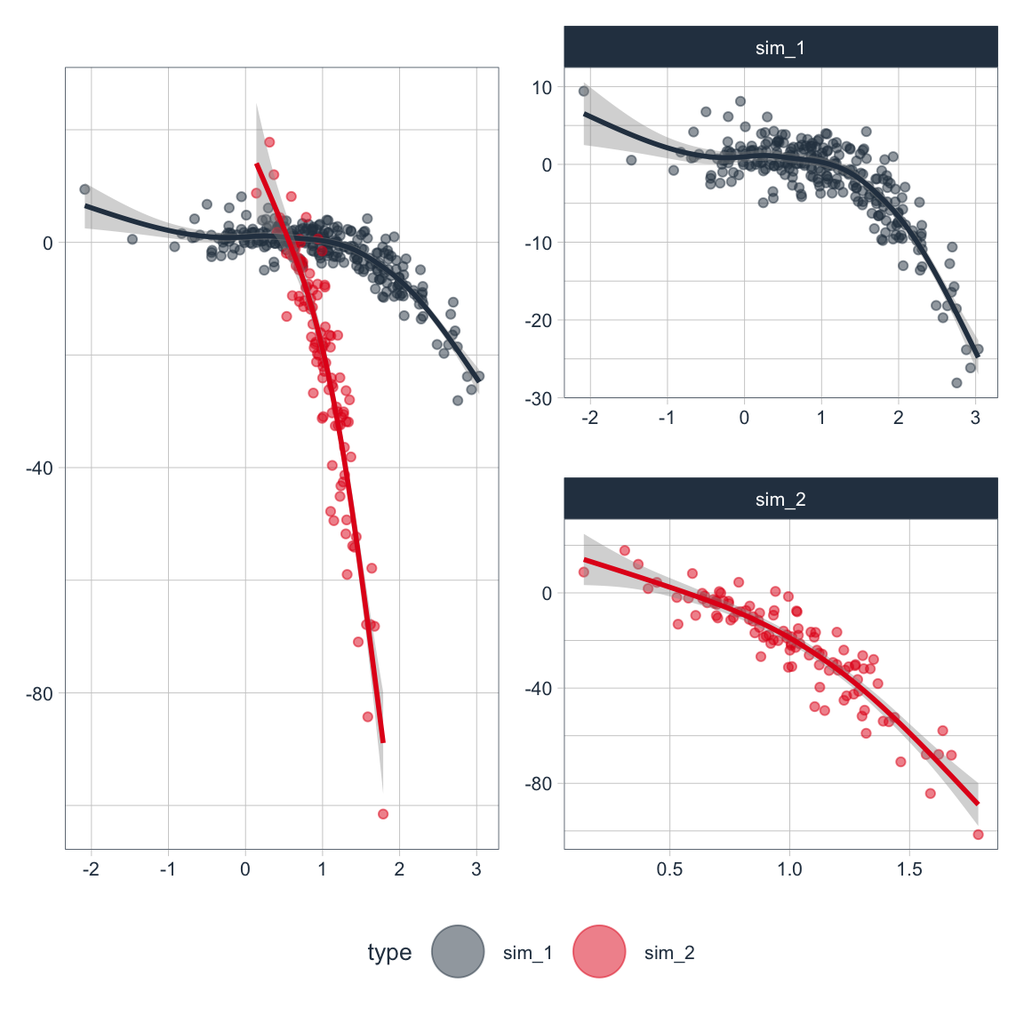

```r
p1 <- sim_data %>%
    ggplot(aes(x, y, col = type)) +
    geom_point(alpha = 0.5) +
    geom_smooth(method = "gam", show.legend = FALSE) +
    scale_color_tq() +
    labs(x = NULL, y = NULL)  +
    guides(colour = guide_legend(override.aes = list(size = 10))) +
    theme(text = element_text(size = 10))

p2 <- sim_data %>%
    ggplot(aes(x, y, col = type)) +
    geom_point(alpha = 0.5) +
    geom_smooth(method = "gam",  show.legend = FALSE) +
    scale_color_tq() +
    labs(x = NULL, y = NULL)  +
    facet_wrap(vars(type), ncol = 1, scales = "free") +
    guides(colour = guide_legend(override.aes = list(size = 10))) +
    theme(text = element_text(size = 10))

p1 + p2 + plot_layout(guides = 'collect', ncol = 2)
```

# MODEL 1: Linear Model

The first model that we are going to create is a bayesian version of a classical linear regression. - LINEAR (BAD FOR NON LINEAR PROBLEM) - NO HIERACHY

So, due to the fact that we will using a linear regression we will model our data as follow:

$$y = \alpha \; + \; \beta x_{i} \; + \;
\epsilon_{i}$$
But we will train int using the *MCMC* and not the ordinary least squares (*OLS*).

## Fit the Model

```r
#workflow_bayesian_fit_1 <-
#     fit(workflow_bayesian_1, data = sim_data)

#workflow_bayesian_fit_1$fit$fit$fit %>%  plot()

#write_rds(workflow_bayesian_fit_1, "models/workflow_bayesian_fit_1.rds")

workflow_bayesian_fit_1 <- read_rds("models/workflow_bayesian_fit_1.rds")

predictions_bayes_tbl_1 <-
    workflow_bayesian_fit_1 %>%
    create_prediction()

plot_model_1 <- predictions_bayes_tbl_1 %>%
    plot_bayesian_model() +
    labs(x = NULL, y = NULL, title = "First Bayesian model",
         subtitle = "Global Linear, NO hierarchy (BAD)")
```

# MODEL 2

NON-LINEAR : - NON-LINEAR (GOOD FOR NON LINEAR PROBLEM) - NO HIERACHY (BAD)

## Create thw workflow

```r
model_spec_bayesian_2 <- bayesian(
    mode = "regression",
    family = gaussian(),
    engine = "brms",
    formula.override = bayesian_formula(y ~ s(x))
)

recipe_spec_bayesian_2  <- recipe(y ~ x, sim_data)

workflow_bayesian_2 <-
    workflow() %>%
    add_model(model_spec_bayesian_2,
              # unfortunately tidymodels as u bug so we have to enter a formula
              # the formula will not be considered so is
              # not importat what we write
              formula = y ~ x) %>%
    add_recipe(recipe_spec_bayesian_2)
```

## Fit the Model

```r
#workflow_bayesian_fit_2 <-
#    fit(workflow_bayesian_2, data = sim_data)

#workflow_bayesian_fit_2$fit$fit$fit %>%  plot()

#write_rds(workflow_bayesian_fit_2, "models/workflow_bayesian_fit_2")

workflow_bayesian_fit_2 <- read_rds("models/workflow_bayesian_fit_2")



predictions_bayes_tbl_2 <-
    workflow_bayesian_fit_2 %>%
    create_prediction()

plot_model_2 <- predictions_bayes_tbl_2 %>%
    plot_bayesian_model() +
    labs(x = NULL, y = NULL, title = "Second Bayesian model",
         subtitle = "Global NON-Linear (Better but still BAD)")
```

# MODEL 3

NON-LINEAR AND HIERARCHICAL: - NON-LINEAR (GOOD FOR NON LINEAR PROBLEM) - YES HIERARCHICAL (GOOD) - GLOBAL VARIANCE (BAD)

## Create the workflow

```r
model_spec_bayesian_3 <- bayesian(
    mode = "regression",
    family = gaussian(),
    engine = "brms",
    formula.override = bayesian_formula(
        y ~ s(x, by = type) + (1 | type)
    )
)

recipe_spec_bayesian_3  <- recipe(y ~ x + type, sim_data)

workflow_bayesian_3 <-
    workflow() %>%
    add_model(model_spec_bayesian_3,
              # unfortunately tidymodels as u bug so we have to enter a formula
              # the formula will not be considered so is
              # not importat what we write
              formula = y ~ x) %>%
    add_recipe(recipe_spec_bayesian_3)
```

## Fit the Model

```r
#workflow_bayesian_fit_3 <-
#    fit(workflow_bayesian_3, data = sim_data)

#workflow_bayesian_fit_3$fit$fit$fit %>%  plot()

#write_rds(workflow_bayesian_fit_3, "models/workflow_bayesian_fit_3")

workflow_bayesian_fit_3 <- read_rds("models/workflow_bayesian_fit_3")


predictions_bayes_tbl_3 <-
    workflow_bayesian_fit_3 %>%
    create_prediction()


plot_model_3 <- predictions_bayes_tbl_3 %>%
    plot_bayesian_model() +
    labs(x = NULL, y = NULL, title = "Third Bayesian model",
         subtitle =
             "Groupwise Bayesian GAM (Hierarchical Good, global variance BAD)")
```

# MODEL 4

NON-LINEAR AND HIERARCHICAL AND GROUP VARIANCE: - NON-LINEAR (GOOD FOR NON LINEAR PROBLEM) - YES HIERARCHICAL (GOOD) - GROUP VARIANCE (GOOD)

## Create the workflow

```r
model_spec_bayesian_4 <- bayesian(
    mode = "regression",
    family = gaussian(),
    engine = "brms",
    formula.override = bayesian_formula(
        bf(
            y ~ s(x, by = type) + (1 | type),
            sigma ~s(x, by = type) + (1 | type)
        )
    )
)

recipe_spec_bayesian_4  <- recipe(y ~ x + type, sim_data)

workflow_bayesian_4 <-
    workflow() %>%
    add_model(model_spec_bayesian_4,
              # unfortunately tidymodels as u bug so we have to enter a formula
              # the formula will not be considered so is
              # not importat what we write
              formula = y ~ x)
    add_recipe(recipe_spec_bayesian_4)
```

## Fit the Model

```r
#workflow_bayesian_fit_4 <-
#    fit(workflow_bayesian_4, data = sim_data)

#workflow_bayesian_fit_4$fit$fit$fit %>%  plot()

#write_rds(workflow_bayesian_fit_4, "models/workflow_bayesian_fit_4")


workflow_bayesian_fit_4 <- read_rds("models/workflow_bayesian_fit_4")

predictions_bayes_tbl_4 <-
    workflow_bayesian_fit_4 %>%
    create_prediction()


plot_model_4 <- predictions_bayes_tbl_4 %>%
    plot_bayesian_model() +
    labs(x = NULL, y = NULL, title = "Fourth Bayesian model",
         subtitle =
             "Groupwise Bayesian GAM (Hierarchical Good, Group variance Good)")
```

# Model visualization

Here are reported all the 4 methods together in order to see the difference and out the performance improve going from the simplest model to the most complex

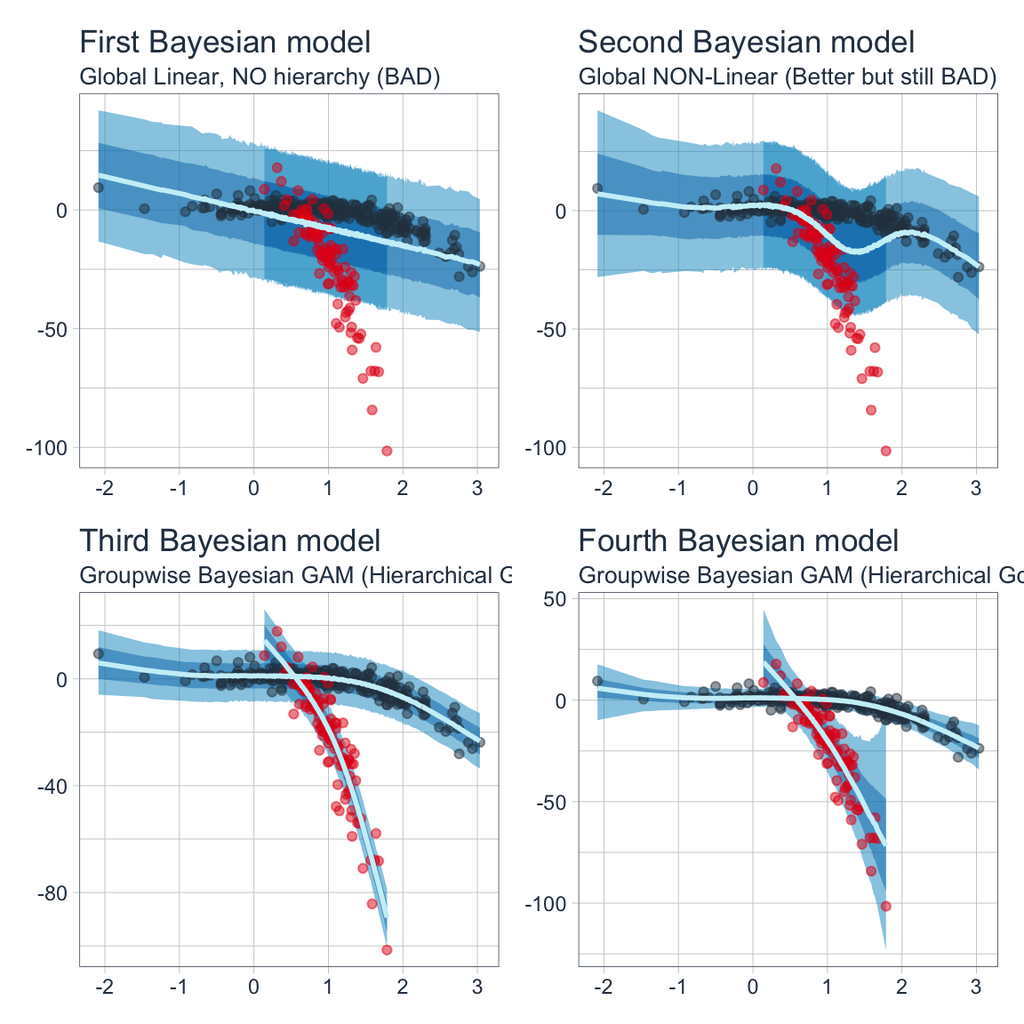

```r
plot_model_1 + plot_model_2 + plot_model_3 + plot_model_4
```